# Association rules

Movie recommender systems

Aryan Tajmirriahi

2018-07-22 02:37:48

> با استفاده از داده نظرهای فیلم به سوالات زیر پاسخ دهید.

در این تمرین با توجه به حجیم بودن داده سعی شده تا حد امکان از data.table به جای dplyr استفاده شود.

```r
library(readr)
library(dplyr)
library(stringr)
library(data.table)
```

```r
library(highcharter)
library(ggplot2)
library(arules)
library(arulesViz)
library(colorspace)
library(stringr)
library(stopwords)
moviz = read_delim("E://edu//TahlilDade//ml-10M100k//movies.dat", delim = "::",
                   col_names = c("MovieID", NA, "Title", NA, "Genres")) %>% select(1,3,5)
# moviz %>% head %>% View()
t_moviz = as.data.table(moviz)

data.frame(MovieID=c(NA), Title=c(NA), Genre=c(NA)) -> genre_moviz
for (i in 1:dim(moviz)[1]) {
  moviz[i,] %>% .$Genres %>%  str_extract_all("\\w+") %>% .[[1]] -> genres
  moviz[i,] %>% .$MovieID ->movieid
  moviz[i,] %>% .$Title -> title
  for (genre in genres) {
    data.frame(MovieID=c(movieid), Title=c(title), Genre=c(genre)) %>% rbind(genre_moviz)->genre_moviz
  }
}
genre_moviz %>%
  .[complete.cases(.),] ->genre_moviz
# genre_moviz %>%  arrange(MovieID) %>% head %>% View()
t_genre_moviz = as.data.table(genre_moviz)


tags = read_delim("E://edu//TahlilDade//ml-10M100k//tags.dat", delim = "::",
                  col_names = c("UserID", NA, "MovieID", NA, "Tag", NA, "Timestamp")) %>%
  select(1,3,5, 7)
# tags %>% head %>% View()
t_tags = as.data.table(tags)


rating = read_delim("E://edu//TahlilDade//ml-10M100k//ratings.dat", delim = "::",
                    col_names = c("UserID", NA, "MovieID", NA, "Rating", NA, "Timestamp")) %>%
  select(1,3,5, 7)
# rating %>% head %>% View()
t_rating = as.data.table(rating)
```

۱. آماره های زیر را بیابید. الف. محبوب ترین فیلم کدام است؟ ب. بیشترین نظرات درباره چه فیلمی داده شده است؟ پ. منفورترین فیلم کدام است؟ ت. تعداد فیلم های ساخته شده در هر سال ث. در هر سالی مردم به چه ژانری علاقه مند بوده اند.

```r
t_rating[,.(tot_rat=mean(Rating, na.rm=TRUE), num_rat=.N), by=.(MovieID)][t_moviz,,on=.(MovieID)][order(desc(tot_rat)),,] %>% View()
t_tags[,.(num = .N), by=.(MovieID)][t_moviz,,on=.(MovieID)][order(desc(num)),,] %>% View()
t_rating[,.(tot_rat=mean(Rating, na.rm=TRUE)), by=.(MovieID)][t_moviz,,on=.(MovieID)][order(tot_rat),,] %>% View()
t_moviz[,.(year = as.integer(str_sub(str_extract(Title, "\\(\\d+\\)"), 2, 5))),][!is.na(year),.(num = .N), by=.(year)][order(desc(num)),,] %>% View()
t_moviz[,.(Genres, Title, MovieID, year = as.integer(str_sub(str_extract(Title, "\\(\\d+\\)"), 2, 5))),][!is.na(year),,][t_rating,,on=.(MovieID)][,.(mscore=mean(Rating, na.rm=TRUE)),by=.(year, Genres)][!is.na(year),,][ order(desc(mscore)),,] %>% group_by(year) %>% slice(1) %>% View()
```

[output not shown]

۲. ژانر فیلم ها را استخراج نمایید. سپس آماره های زیر را استخراج نمایید. الف. نمودار ستونی تعداد فیلم های هر ژانر ب. نمودار همبستگی ژانرها پ. متوسط امتیاز به هر ژانر ت. دوران طلایی فیلم سازی

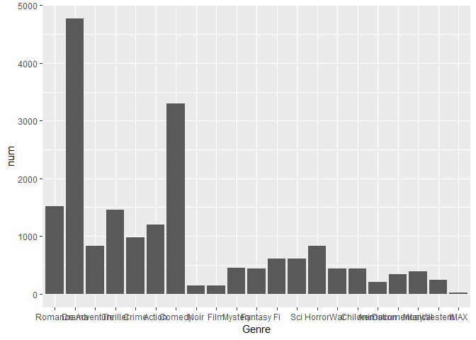

```r
t_genre_moviz[,.(num = .N), by=.(Genre)][num>5,,][order(num)] ->genres
genres%>% ggplot(aes(x= Genre, y = num), data = .)  +geom_col()
```

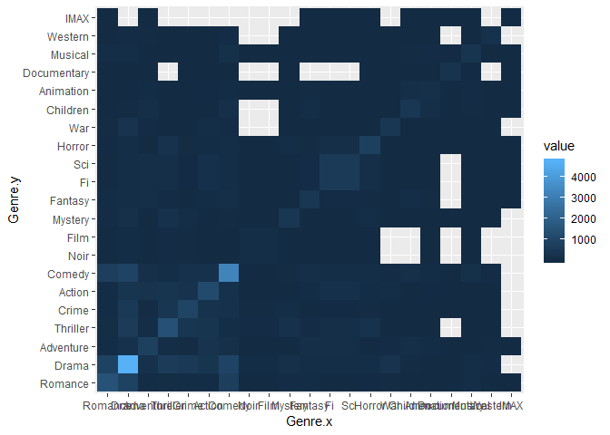

```r
genre_moviz %>% filter(Genre %in% genres$Genre) %>%
  full_join(., ., by=c("MovieID")) %>% group_by(Genre.x, Genre.y) %>% summarise(value=n()) %>%
  ggplot(aes(x=Genre.x, y=Genre.y, fill=value)) + geom_tile()
```

۳. نمودار ابر لغات را بر حسب کلمات عنوان فیلم ها رسم نمایید.

```r
wstone = moviz$Title %>%
  str_replace_all("\"","") %>%
  str_replace_all("[[:punct:]]","") %>%
  str_split(pattern = "\\s") %>%
  unlist() %>%
  table() %>%
  as.data.frame(stringsAsFactors = F)
colnames(wstone) = c("word","count")
wstone$word = str_to_lower(wstone$word)
wstone = wstone %>%
  filter(!str_to_lower(word) %in% stopwords()) %>%
  filter(str_length(word)>1) %>%
  filter(!str_detect(word,"\\d")) %>%
  arrange(desc(count))
library(tm)
stopwords()
```

[output not shown]

[output cut: 20 more lines]

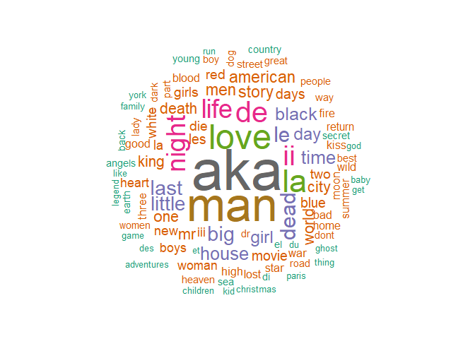

```r
library(wordcloud)
wordcloud(wstone$word[1:100],wstone$count[1:100],
          c(5,.3), random.order = FALSE, color = brewer.pal(8, "Dark2"), random.color = FALSE)
```

- Castle in the Sky (1986)
- Cast Away (2000)
- No Country for Old Men (2007)
- Memento (2000)

```r
full_join(rating, moviz) %>%
  .[complete.cases(.),] %>%
  group_by(Rating, UserID) %>%
  summarise(str = paste(Title, collapse = ";")) -> str_transaction
transaction = lapply(str_transaction$str,FUN = function(x) strsplit(x,split = ";")[[1]])
t_tra <- as(transaction, "transactions")
myrules = apriori(t_tra, parameter = list(support = 0.001,
                                             confidence = 0.25, minlen = 2))
```

```
## Apriori
##
## Parameter specification:
##  confidence minval smax arem  aval originalSupport maxtime support minlen
##        0.25    0.1    1 none FALSE            TRUE       5   0.001      2
##  maxlen target   ext
##      10  rules FALSE
##
## Algorithmic control:
##  filter tree heap memopt load sort verbose
##     0.1 TRUE TRUE  FALSE TRUE    2    TRUE
##
## Absolute minimum support count: 408
##
## set item appearances ...[0 item(s)] done [0.00s].
## set transactions ...[9349 item(s), 408191 transaction(s)] done [1.99s].
## sorting and recoding items ... [3053 item(s)] done [0.38s].
## creating transaction tree ... done [0.55s].
## checking subsets of size 1 2 3
```

```
##  done [18.95s].
## writing ... [254691 rule(s)] done [0.10s].
## creating S4 object  ... done [0.16s].
```

```r
# yourrules = subset(myrules, items %in% c("Memento (2000)", "Cast Away (2000)", "Castle in the Sky (Tenkû no shiro Rapyuta) (1986)"))
# inspect(sort(yourrules, by = "lift")[1:10]) #inspecting those films
```

۵. تمرین سخت: در گیت هاب برای خود اکانت درست کنید. همه تمرین های خود را آنجا بارگذاری کنید! و لینک آن را ارسال نمایید.

https://github.com/artajmir3/TahlilDade

۶. پنج انتقاد از درس و نحوه تدریس را بیان کنید.

۷. پنج پیشنهاد برای بهتر شدن درس بیان کنید.

۸. سه موضوع آماری جدید برای جایگزینی در سرفصل ها پیشنهاد دهید.

۹. سه داده جالب برای کار در کلاس پیشنهاد دهید.

۱- داده های تبلیغات یک سایت و موفق بودن یا نبودن آنها. ۲- داده های هواشناسی ۳- داده های مربوط به ترافیک

۱۰. چهار نکته مهمی که در کلاس یاد گرفتید را بیان کنید.